# Tooth Growth

Andrea Castagna

8/2/2021

## The Effect of Vitamin C on Tooth Growth in Guinea Pigs

# Basic Inferential Data Analysis

# Main question: DO DELIVERY METHOD AND/OR DOSAGE AFFECT TOOTH GROWTH IN GUINEA PIGS?

# 1.Overview

*The Tooth Growth data set contains information about an experiment regarding odontoblasts cells in 60 guinea pigs.*

*The response is the length of odontoblasts (cells responsible for tooth growth) in 60 guinea pigs.* *Each animal received one of three dose levels of vitamin C (0.5, 1, and 2 mg/day)* *by one of two delivery methods, orange juice or ascorbic acid (a form of vitamin C and coded as VC).*

```r
library(ggplot2)
library(ggpubr)
library(tidyr)
library(stringr)
library(dplyr)
data("ToothGrowth")

head(ToothGrowth)
```

```
##    len supp dose
## 1  4.2   VC  0.5
## 2 11.5   VC  0.5
## 3  7.3   VC  0.5
## 4  5.8   VC  0.5
## 5  6.4   VC  0.5
## 6 10.0   VC  0.5
```

```r
tail(ToothGrowth)
```

```
##     len supp dose
## 55 24.8   OJ    2
## 56 30.9   OJ    2
## 57 26.4   OJ    2
## 58 27.3   OJ    2
## 59 29.4   OJ    2
## 60 23.0   OJ    2
```

```r
str(ToothGrowth)
```

```
## 'data.frame':    60 obs. of  3 variables:
##  $ len : num  4.2 11.5 7.3 5.8 6.4 10 11.2 11.2 5.2 7 ...
##  $ supp: Factor w/ 2 levels "OJ","VC": 2 2 2 2 2 2 2 2 2 2 ...
##  $ dose: num  0.5 0.5 0.5 0.5 0.5 0.5 0.5 0.5 0.5 0.5 ...
```

*Tooth Growth is data frame with 60 observations on 3 variables.*

1. len *numeric* *Tooth length*
2. supp *factor* *Supplement type (VC or OJ)*
3. dose *numeric* *Dose in milligrams/day*

*Source*

*C. I. Bliss (1952). The Statistics of Bioessay. Academic Press.*

*References*

*McNeil, D. R. (1977). Interactive Data Analysis. New York: Wiley.* *Crampton, E. W. (1947). The growth of the odontoblast of the incisor teeth as a criterion of vitamin C intake of the guinea pig. The Journal of Nutrition, 33(5), 491–504. doi: 10.1093/jn/33.5.491.*

# 1.2 Exploratory Data Analysis

_Our first step is to take a glance at our dataset and use the function *summary* to check what are the main characteristics of our two data points: Length of the Teeth Growth (*len*) and the amount of Dose subministrated to the 60 Guinea Pigs (*dose*).

We can see that the Mean of Tooth Growth is *18.81*

We also proceed to check if our lengths follow a normal distribution with one of the many check available in the *normtest* ( *https://cran.r-project.org/web/packages/normtest/normtest.pdf_ ) package, in our case we opt for the Shapiro-Wilk normality test*_

In this test, we need to evaluate the p-value, if it’s higher than *> 0.05* or variable is *normally distributed*

In our case its p-value is **0.1091** which is greater than **0.05**.

Our variable is normally distributed with a slight left skew.

```r
summary(ToothGrowth)
```

```
##       len        supp         dose
##  Min.   : 4.20   OJ:30   Min.   :0.500
##  1st Qu.:13.07   VC:30   1st Qu.:0.500
##  Median :19.25           Median :1.000
##  Mean   :18.81           Mean   :1.167
##  3rd Qu.:25.27           3rd Qu.:2.000
##  Max.   :33.90           Max.   :2.000
```

```r
shapiro.test(ToothGrowth$len)
```

```
##
##  Shapiro-Wilk normality test
##
## data:  ToothGrowth$len
## W = 0.96743, p-value = 0.1091
```

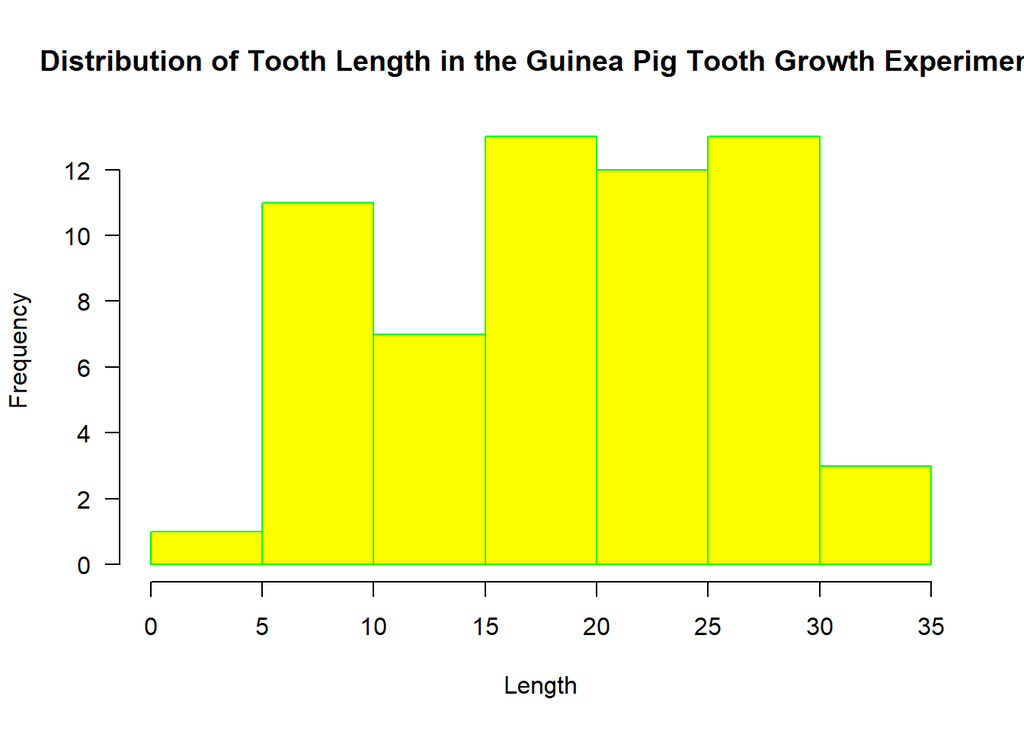

```r
hist(ToothGrowth$len, main = "Distribution of Tooth Length in the Guinea Pig Tooth Growth Experiment", xlab = "Length", ylab = "Frequency", border = "green", col = "yellow", las =1)
```

```r
hist(ToothGrowth$len, main = "Density of Tooth Length in the Guinea Pig Tooth Growth Experiment with density curved superimposed", xlab = "Length", ylab = "Density", border = "Red", col = "Black", las =1, freq = FALSE)
1
```

```
## [1] 1
```

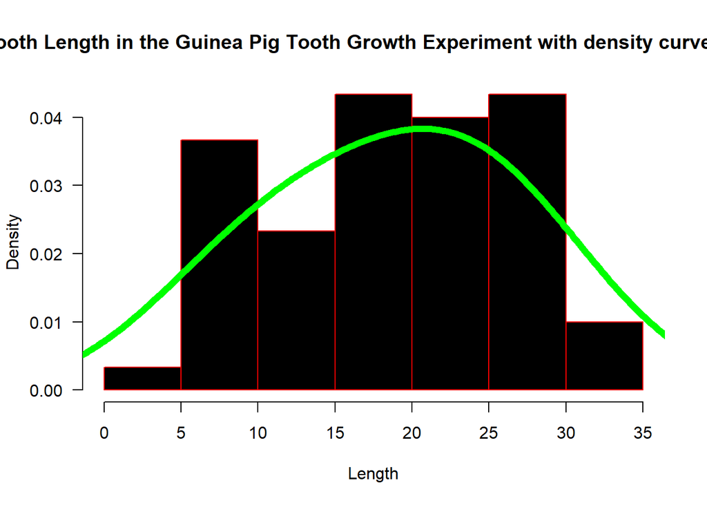

```r
lines(density(ToothGrowth$len, adjust = 2),lwd = 6, col = "green")
```

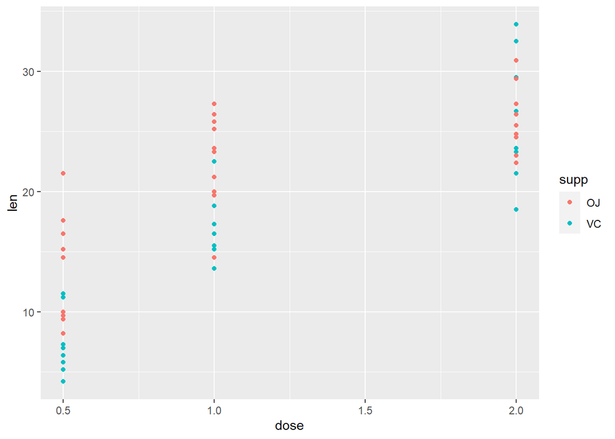

```r
# Overlaid histograms with means
#plot1 <- ggplot(ToothGrowth, aes(x=len, y=dose, fill=supp)) +geom_bar(alpha=.5, stat = "identity")

#plot1 this graph is wrong, the y axis is wrong

plot2 <- quickplot(dose, len, data = ToothGrowth, colour=supp)

plot2
```

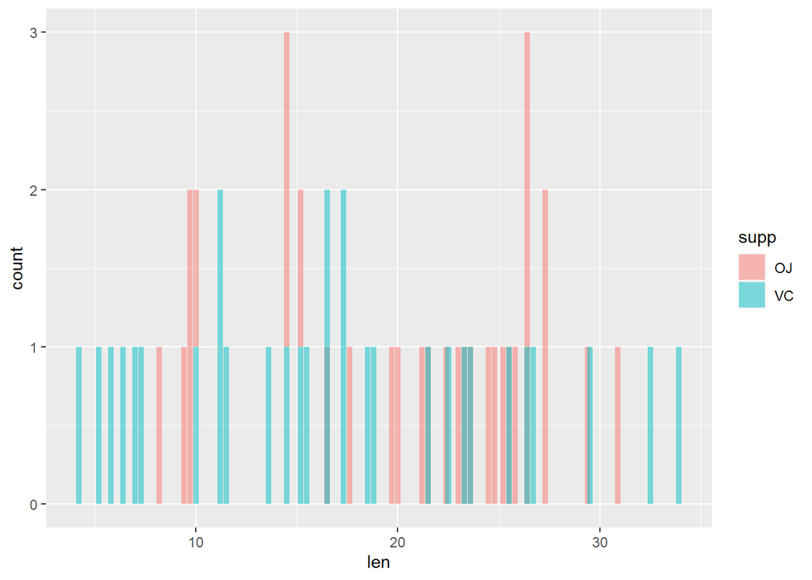

```r
plot3 <- ggplot(ToothGrowth, aes(x=len,fill=supp)) +geom_bar(alpha=.5)

plot3
```

```r
quicksummary <-ToothGrowth %>% group_by(supp) %>% summarize(count = n())

orangejuice <- ToothGrowth %>% filter(supp == "OJ")

ascorbicacid <- ToothGrowth %>% filter(supp == "VC")
```